# E.Coli levels in Utah Lake- Final Project

Kara Galloway

2024-04-25

### Background

In the summer of 2023 I had the opportunity to be a part of the Utah Lake Project. This project included various UVU professors and students, assembled into teams, setting out to study various aspects of Utah Lake. I was privileged to be a part of the microbiology team with Dr. Lauren Brooks!

[figure not shown]

My lab partner and I spend the summer sampling water from sites around Utah Lake. We used these samples to test for E. coli using what is called a Quanti-tray Analysis.

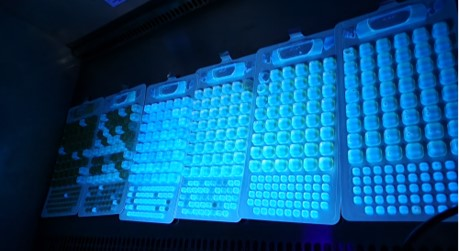

### I am going to use the E. coli data I collected to ask two questions:

**- 1. Does a site’s average distance to farmland affect E. coli levels measured there?**  
*(Why does this matter?: E. coli bacteria is abundantly found in fecal matter- a byproduct of livestock! Peek this image of us working on public relations with the culprit in question)*

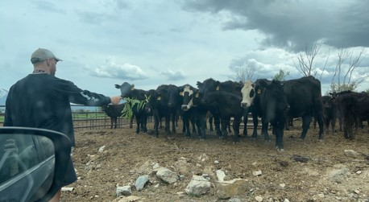

**- 2. Does precipitation level affect average E. coli levels on any given day?**  
*(Why does this matter?: Precipitation can affect the amount of runoff into the lake, bringing bacteria with it! Peek this image of last summer’s flooding during our project)*

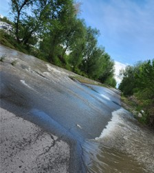

Before we get much further, here is a look at the sample data I collected

| Site | Level | Date |
| --- | --- | --- |
| AFM Creek | 36.4 | 5/16/2023 |
| AFM Creek | 24.3 | 5/23/2023 |
| AFM Creek | 4.1 | 6/6/2023 |
| AFM Creek | 2.0 | 6/13/2023 |
| AFM Gulf | 20.3 | 5/16/2023 |
| AFM Gulf | 149.7 | 5/23/2023 |
| AFM Gulf | NA | 5/30/2023 |
| AFM Gulf | 1011.2 | 6/6/2023 |
| AFM Gulf | 38.3 | 6/13/2023 |
| Goose Point North | 74.8 | 5/18/2023 |
| Goose Point North | 81.2 | 5/25/2023 |
| Goose Point North | 25.6 | 6/1/2023 |
| Goose Point North | 9.1 | 6/8/2023 |
| Goose Point North | 111.2 | 6/15/2023 |
| Goose Point South | 25.7 | 5/18/2023 |
| Goose Point South | 81.2 | 5/25/2023 |
| Goose Point South | 18.1 | 6/1/2023 |
| Goose Point South | 14.9 | 6/8/2023 |
| Goose Point South | 1011.2 | 6/15/2023 |
| Lincoln Point Marina | 6.3 | 5/18/2023 |
| Lincoln Point Marina | 5.2 | 5/25/2023 |
| Lincoln Point Marina | 1.0 | 6/1/2023 |
| Lincoln Point Marina | 1.0 | 6/8/2023 |
| Lincoln Point Marina | 5.2 | 6/15/2023 |
| Lindon Marina | 2.0 | 5/16/2023 |
| Lindon Marina | 9.6 | 5/23/2023 |
| Lindon Marina | 0.0 | 5/30/2023 |
| Lindon Marina | 3.1 | 6/13/2023 |
| Lindon Marina | 2.0 | 6/6/2023 |
| Mulberry Beach | 4.1 | 5/18/2023 |
| Mulberry Beach | 1.0 | 5/25/2023 |
| Mulberry Beach | 4.1 | 6/1/2023 |
| Mulberry Beach | 2.0 | 6/8/2023 |
| Mulberry Beach | 17.1 | 6/15/2023 |
| Pelican Bay | 21.8 | 5/16/2023 |
| Pelican Bay | 3.1 | 5/23/2023 |
| Pelican Bay | 0.0 | 5/30/2023 |
| Pelican Bay | 2.0 | 6/6/2023 |
| Pelican Bay | 0.0 | 6/13/2023 |
| RV Camp | 11.0 | 5/16/2023 |
| RV Camp | 23.1 | 5/23/2023 |
| RV Camp | 56.8 | 5/30/2023 |
| RV Camp | 111.2 | 6/6/2023 |
| RV Camp | 13.2 | 6/13/2023 |
| Sandy Beach Bay | 316.9 | 5/18/2023 |
| Sandy Beach Bay | 34.5 | 5/25/2023 |
| Sandy Beach Bay | 59.1 | 6/1/2023 |
| Sandy Beach Bay | 86.3 | 6/8/2023 |
| Sandy Beach Bay | 1011.2 | 6/15/2023 |
| Sandy Beach Inlet | 78.2 | 5/18/2023 |
| Sandy Beach Inlet | 34.5 | 5/25/2023 |
| Sandy Beach Inlet | 52.9 | 6/1/2023 |
| Sandy Beach Inlet | 71.0 | 6/8/2023 |
| Sandy Beach Inlet | 601.5 | 6/15/2023 |
| Shoreline Trail | 101.4 | 5/16/2023 |
| Shoreline Trail | 32.4 | 5/23/2023 |
| Shoreline Trail | 50.4 | 5/30/2023 |
| Shoreline Trail | 960.6 | 6/6/2023 |
| Shoreline Trail | 829.7 | 6/13/2023 |

Here’s what it looks like in dot plot form

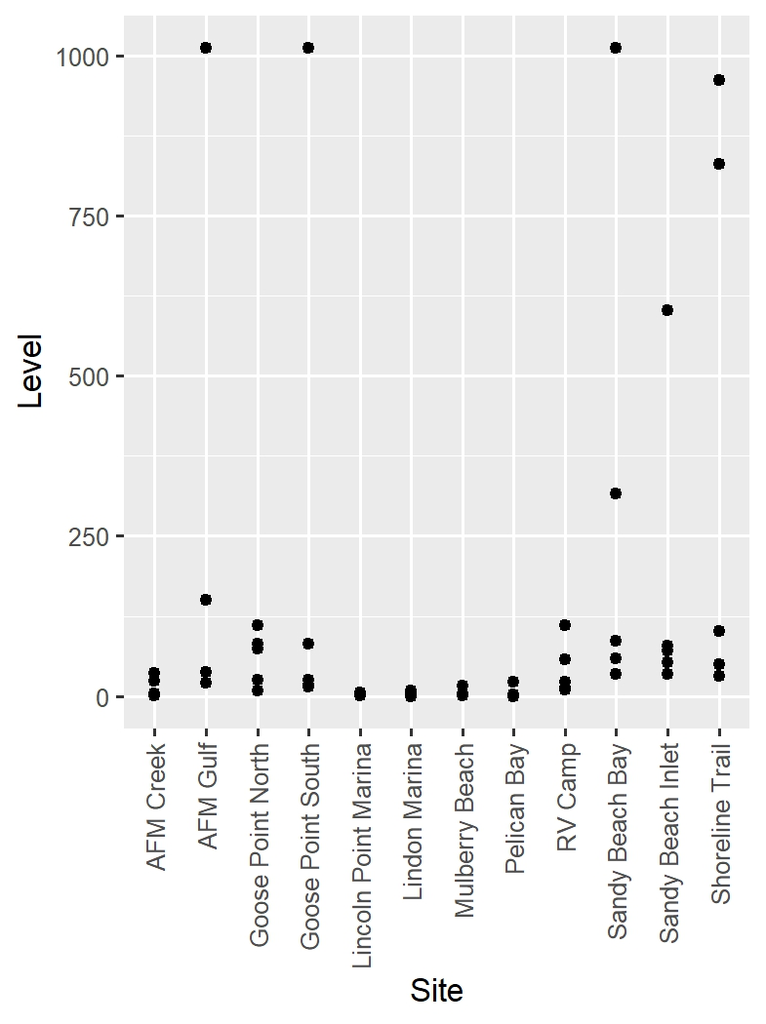

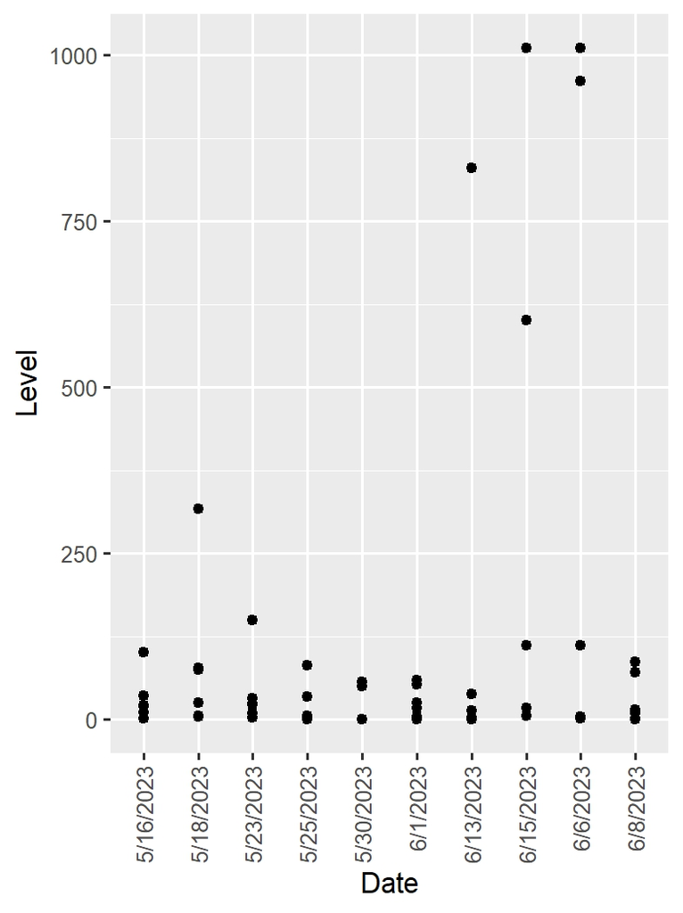

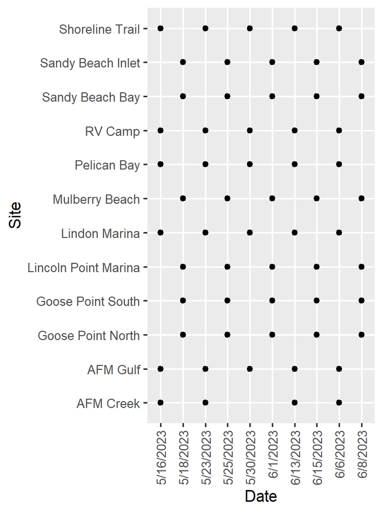

### Question Number 1

#### Does a site’s average distance to farmland affect E. coli levels measured there?

First, let’s look at the table I created for the 5 closest farms to each of 7 sites

| Closest.site | Farm.Name | Distance..mi. |
| --- | --- | --- |
| AFM Creek | Oliver’s Place | 1.84 |
| AFM Creek | Blackhurst Farm | 1.04 |
| AFM Creek | Bushman Cattle Farm | 2.83 |
| AFM Creek | Chaston Livestock | 2.76 |
| AFM Creek | Cox Farm and Ranch | 2.79 |
| Goose Point South | Beere Cattle Company | 5.44 |
| Goose Point South | Circle C Dairy | 7.00 |
| Goose Point South | Rockin E | 6.24 |
| Goose Point South | Wilson Brother’s Cattle | 6.86 |
| Goose Point South | Galt Farms | 8.25 |
| Lincoln Point Marina | Galt Farms | 5.42 |
| Lincoln Point Marina | The Goodbye Lane | 5.15 |
| Lincoln Point Marina | Wilson Brother’s Cattle | 5.51 |
| Lincoln Point Marina | Thunder Rose Ranch | 6.64 |
| Lincoln Point Marina | Beere Cattle Company | 4.75 |
| Lindon Marina | Oliver’s Place | 4.24 |
| Lindon Marina | Bunnell Farms | 4.02 |
| Lindon Marina | Blackhurst Farm | 6.52 |
| Lindon Marina | Clifford Family Farms | 4.69 |
| Lindon Marina | Cherry Hill | 3.31 |
| Mulberry Beach | The Goodbye Lane | 7.28 |
| Mulberry Beach | Galt Farms | 7.23 |
| Mulberry Beach | Wilson Brother’s Cattle | 6.73 |
| Mulberry Beach | Beere Cattle Company | 5.60 |
| Mulberry Beach | Thunder Rose Ranch | 8.77 |
| Pelican Bay | Christiansen’s Family Farm | 8.00 |
| Pelican Bay | Millbrook Farms | 7.10 |
| Pelican Bay | Chaston Livestock | 5.23 |
| Pelican Bay | Cox Farm and Ranch | 5.86 |
| Pelican Bay | Bushman Cattle Farm | 6.15 |
| Sandy Beach Bay | The Goodbye Lane | 1.80 |
| Sandy Beach Bay | Thunder Rose Ranch | 3.16 |
| Sandy Beach Bay | Jones Creek Beef | 4.62 |
| Sandy Beach Bay | Snow Dairy | 6.97 |
| Sandy Beach Bay | Utah Sheep and Cattle | 6.81 |

And a figure too

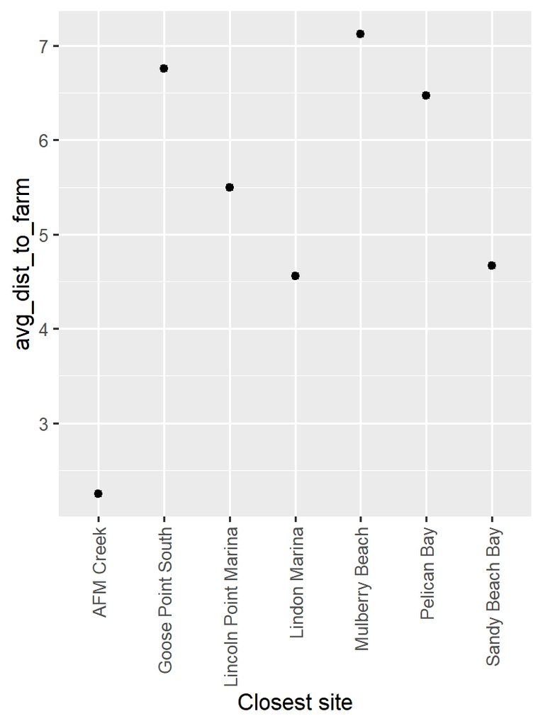

FIGURE 4 - Avg Dist to Farms vs Site

Using cor.test, I tried to see if there was a correlation between E. coli levels and distance to farmland

`cor.test(merged$avg_dist_to_farm, merged$avg_ecoli_count)`  
#### Result… 0.07 … No correlation! I was really hoping there would be!

#### Discussion on Question 1

Thinking about farmland distribution and how waste from farmland makes it into water systems, there are just so many factors involved. Each farm likely has different drainage and irrigation systems. Some are near rivers that feed into the lake, some aren’t. Some use flood irrigation, some don’t. I think if I could somehow account for all of these other factors, or measure the output for each farm instead of just distance, that data would show a correlation.

### Question Number 2

#### Does precipitation level affect average E. coli levels on any given day?

Here is a table of the precipitation data for the duration of the project

| Date | Precip |
| --- | --- |
| 5/16/2023 | 0.00 |
| 5/18/2023 | 0.00 |
| 5/23/2023 | 0.30 |
| 5/25/2023 | 0.01 |
| 5/30/2023 | 0.00 |
| 6/1/2023 | 0.00 |
| 6/6/2023 | 0.01 |
| 6/8/2023 | 0.04 |
| 6/13/2023 | 5.00 |
| 6/15/2023 | 13.00 |

Now plotting against average E. coli levels per date

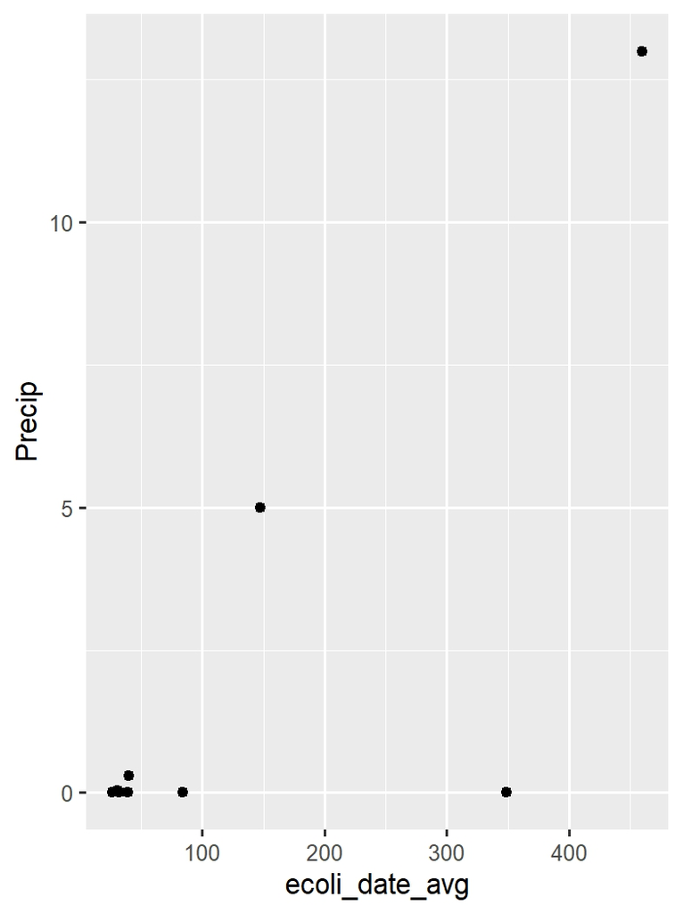

Another correlation test  
`cor.test(precip_merge$ecoli_date_avg, precip_merge$Precip)`

#### Result… 0.75… Strong correlation!!!

#### Discussion on Question 2

I am really happy to see a correlation here! I remember seeing all the crazy flooding and being convinced that our E. coli levels would go up.  
However, my sample size was quite small and over a pretty short time period. I think if my data set had been larger I would have gotten a more convincing correlation here.

### Conclusion

The biggest take-away for me was honestly: I wish I had more data!!! This project really made me want to keep studying Utah Lake so I could find some really solid correlations. I really enjoyed being able to use my own data for this final project and learn so many things about R.